# Challenge

In this challenge, we will study how a "limited slip differential" helps a car that is stuck in the mud. Maybe this has happened to you... maybe it hasn't. But getting stuck in the mud looks like this:

```matlab
%%html
<iframe width="900" height="540" src="https://www.youtube.com/embed/VrS14wLmVhY" frameborder="0" allow="accelerometer; autoplay; encrypted-media; gyroscope; picture-in-picture" allowfullscreen></iframe>
```

[video not shown]

Not a great day! And did you know that it's extremely likely that the other wheel, while also stuck in the mud, is not moving at all? This is because the truck's *differential* is not allowing any torque to be transfered to the wheel with more traction. Why would this be? To understand, we need to understand what a differential in a car actually does.

```matlab
%%html
<iframe width="900" height="540" src="https://www.youtube.com/embed/yYAw79386WI" frameborder="0" allow="accelerometer; autoplay; encrypted-media; gyroscope; picture-in-picture" allowfullscreen></iframe>
```

[video not shown]

As the video shows, a standard differential in a car will actually deliver all of the power ($\dot{W} = T\Omega$) from the transmission to the wheel that is *slipping more*!! This unfortunate reality led to the development of a device called a "limited slip differential," whose operation is explained below.

```matlab
%%html
<iframe width="900" height="540" src="https://www.youtube.com/embed/w2bRb17jJ1U" frameborder="0" allow="accelerometer; autoplay; encrypted-media; gyroscope; picture-in-picture" allowfullscreen></iframe>
```

[video not shown]

You should recognize the concept of *viscous friction* as a catalyst for recovering the lost torque in the axle. You may even consider the effect of the limited slip differential to be similar to that of an *idealized rotational damper*. Today, you will build a very simplified model of a truck's rear axle when it is equipped with a limited slip differential. You will not have any data with which to validate your model, because your job is to *design* a limited slip differential with the "right" damping coefficient $b$. You will use your model to determine what damping coefficient will be acceptable.

But before you begin, it is very true that this system may look extremely daunting. How will you know just where the power goes between the left wheel, the right wheel, the differential, and the viscous damping separating the sliding wheels from the mud?

One thing that may help with model construction (and even scoping) in complex problems like this is to explicitly take advantage of the first law of thermodynamics in the form of continuity and compatibility equations. The easiest way to construct your system model in a way that alllows you to take advantage of these concepts is to represent your *mechanical* system model as a network of *circuit-like elements* so that the relationships needed in developing compatibility and continuity equations are explicit. To represent our mechanical system as an "equivalent circuit," we need to be able to draw solid analogies between power flow in electrical circuits and power flow in mechanical systems.

## Power Variable Types

In all three of the types of systems we've studied, it is possible to write an equation for how work is done between elements. For example:

1. In a mechanical system, power is $F\cdot v$ for translational systems and $T\cdot \Omega$ for rotational systems
2. In an electrical system, power is $V \cdot i$
3. In a fluid system, power is $P \cdot \dot{\mathcal{V}}$.

If the first law of thermodynamics tells us that one of these two variables is conserved at a "node," we interpret this as a statement that it represents a quantity flowing "through" the node. We call this type of variable a "through type variable." In mechanical, electrical, and fluid systems, these are force, current, and flow rate, respectively.

If a variable must be measured with respect to some fixed reference in order to have meaning, and is different from one node in our model to the next, it is called an "across type variable."

For example, velocity must be measured with respect to an inertial reference frame, and varies from one end of an idealized damper to the other. Voltage must be measured with respect to some reference "ground" voltage, and varies from one end of a resistor to another. Pressure must be measured by a gauge which references some environmental (atmospheric) reference pressure, and varies from one end of a valve to the other.

## Generalized Idealized Elements

All of the "idealized" system element types we have talked about thus far, by the assumptions applied to their first law equations, either store energy or transfer it to the surrounding environment. This means that all of the elements we've discussed (other than "nodes") have different amounts of power flowing into and out of them. These elements are often visualized as having two "ports," one into which power flows, and one out of which power flows. A drawing is shown below:

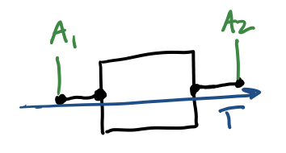

The generalized element above will have two distinct values of the A-type variable at each "end," either because the element is accumulating energy (like a mass, capacitor, or tank does), or because it is transferring energy to outside the system boundaries (like a resistor, damper, or valve).

Visualizing elements in this general way allows us to connect elements of our systems together into generalized "equivalent circuits." Doing this provides *operational efficiency* in using energy conservation (the first law) to build models for our systems.

The first law of thermodynamics for this element could be written:

$$\dot{E} = \dot{W}_{in} - \dot{W}_{out} + \dot{Q}_{in} - \dot{Q}_{out}$$

Then, recognizing that $\dot{W} = A\cdot T$, we could write the *power portion* of the first law equation as:

$$\dot{E} = A_1T - A_2T + \dot{Q}_{in} - \dot{Q}_{out}$$

note that the visualization of our generalized element **does not show** whether the element stores energy or transfers it to the element's surroundings as heat. As such this is **not** a complete energetic diagram. **We need to know what the $\dot{Q}$ terms and the $\dot{E}$ term should be for our element.** These terms are often based on similar sorts of assumptions, and yield two common types of "generalized elements."

### Energy Storage Elements

If an element *stores* energy, but does not transfer it to its surroundings, it is generally called an "energy storage element." If it stores energy via its across-type variable, it is called an "A-type storage element." Masses, rotational inertias, capacitors, and fluid capacitors are all A-type storage elements. If the element stores energy via its through-type variable, it is called a "T-type storage element." For energy storage elements, zero heat transfer to the element's surroundings is often assumed, which reduces the first law equation to:

$$\dot{E} = A_1 T - A_2 T$$

### Dissipative Elements

If an element does not *store* significant energy, but does transfer significant energy to the element's surroundings (usually via heat), we call that element a "dissipative element." Dissipative elements include electrical resistors, valves, and idealized dampers. The assumption of no energy storage for dissipative elements yields the generalized first law balance of:

$$\dot{Q}_{out} = A_1 T - A_2 T$$

### Do all physical things fall into one of these two categories?

No. It may not be reasonable to represent every physical "part" of every system as one of these two things. However, Elements that display significant energy storage *and* energy dissipative behavior can, under many circumstances, be represented by a combination of a dissipative and a storage element. We call this a "lumped element" approximation, where a "real" element is broken down into a combination of idealized storage and dissipative elements.

## Generalized Equivalent Circuits

By conceptualizing each of our idealized elements as having two ports through which power flows, much like an electrical component has, we can arrange the elements into an equivalent circuit that shows us how power flows from one element to another. An example is shown below.

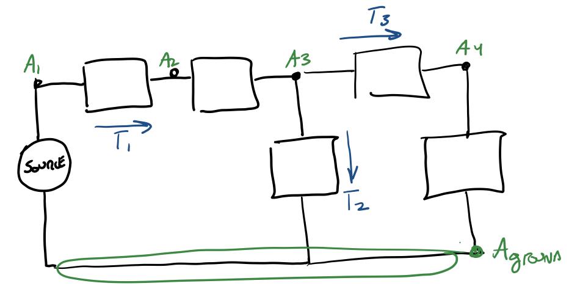

This circuit has a source (which we often model as having a defined, known value for either the T-type or A-type power variable, and thus "infinite" power potential), and 5 idealized elements. Distinct values of the across-type power variable are shown in green, and distinct values of the through-type variable are shown in blue. This circuit-like network allows us to write compatibility relations (loops relating the A type variables) and continuity relations (nodal equations for the T type variables) to aid in model construction.

Note that while this configuration allows for easy use of the first law of thermodynamics for studying how power flows from one element in our system to the others (compatibility and continuity relationships), it **does not** tell us explicitly about energy storage or dissipation for each element. Individual first law balances for each element are required, along with the construction of loop and node equations, to use the equivalent circuit for model construction.

Note that typically, the blank box used to denote each element would include the element's primary parameter. For example, a damper might be drawn as a box with a "b" in it to represent its damping coefficient. A mass might be drawn as a box with an "m" in it. A capacitor might be labeled "C."